# DO Superovulation Genetic Mapping

### Day 2 Number of 2-cells

Heritability: 0.4

Gather phenotype and covariates.

```r
pheno_name = 'DAY2Numb2cells'
ph = pheno[,pheno_name, drop = FALSE]

meta_row  = which(meta$column == pheno_name)
transform = meta$transform[meta_row]

if(!is.na(transform)) {
  if(transform == 'log') {
    ph[,1] = log(ph[,1])
  } else if(transform == 'log1p') {
    ph[,1] = log1p(ph[,1])
  } else if(transform == 'sqrt') {
    ph[,1] = sqrt(ph[,1])
  }
} # if(!is.na(transform))

covar_names = strsplit(meta$covar[meta_row], split = ';')[[1]]
addcovar    = model.matrix(~ ., data = covar[,covar_names, drop = FALSE])[,-1, drop = FALSE]
```

Map phenotype with date,DAY1Numb1cells as covariates.

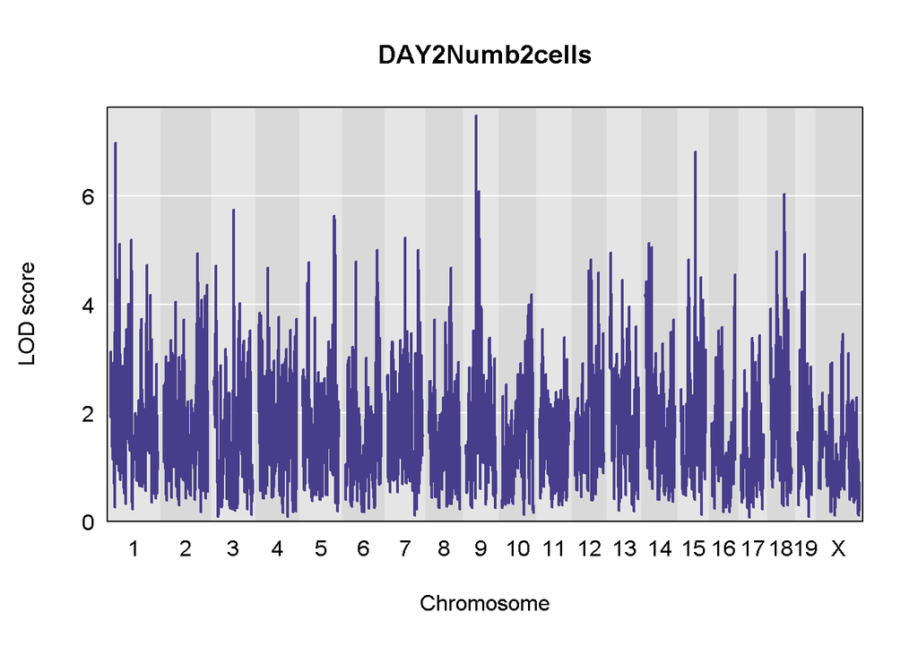

```r
qtl = scan1(genoprobs = probs,
            pheno     = ph,
            kinship   = K,
            addcovar  = addcovar)
plot(qtl, map, main = pheno_name)
```

Map rankZ-transformed phenotype.

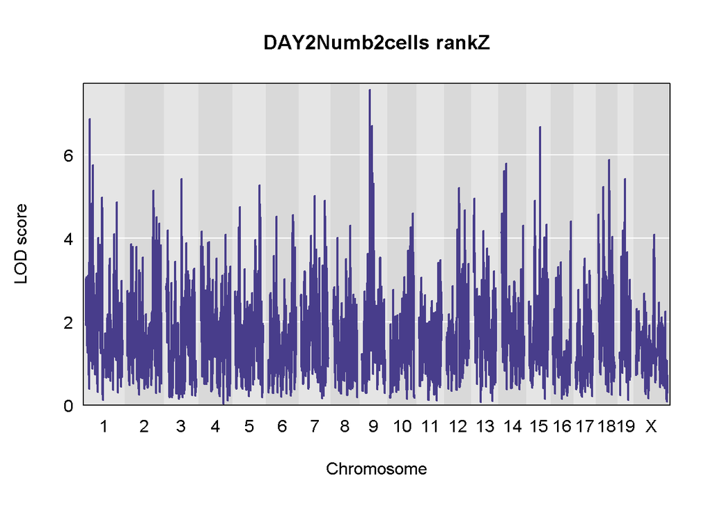

```r
ph  = pheno_rz[,pheno_name, drop = FALSE]
qtl = scan1(genoprobs = probs,
            pheno     = ph,
            kinship   = K,
            addcovar  = addcovar)
plot(qtl, map, main = paste(pheno_name, 'rankZ'))
```

```r
peaks = find_peaks(qtl, map, threshold = 7)
```

```r
perm_file = file.path(results_dir, 'rankz_perms.txt')

if(!file.exists(perm_file)) {
  for(i in 1:10) {
    print(i)
    #t1 = proc.time()[3]
    perms = scan1perm(genoprobs = probs,
                      pheno     = ph,
                      kinship   = K,
                      addcovar  = addcovar,
                      n_perm    = 100)
    #print(proc.time()[3] - t1)
    write(perms, file = perm_file, ncolumns = 1, append = i > 1, sep = '\n')
  } # for(i)
} else {
  perms = scan(perm_file, sep = '\n')
} # else
```

What is the 0.05 threshold with rankZ transformed data?

```r
quantile(perms, 0.95)
```

```
##      95%
## 8.075066
```

Plot the LOD on Chr 9.

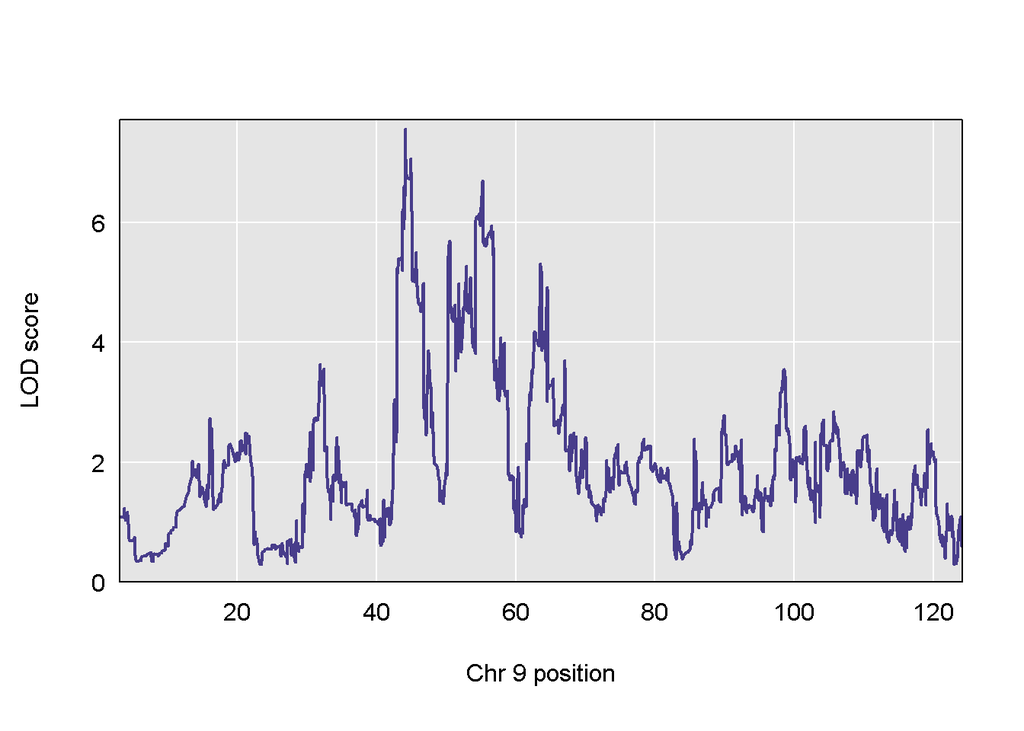

```r
plot(qtl, map, chr = 9)
```

Plot the founder allele effects on Chr 9.

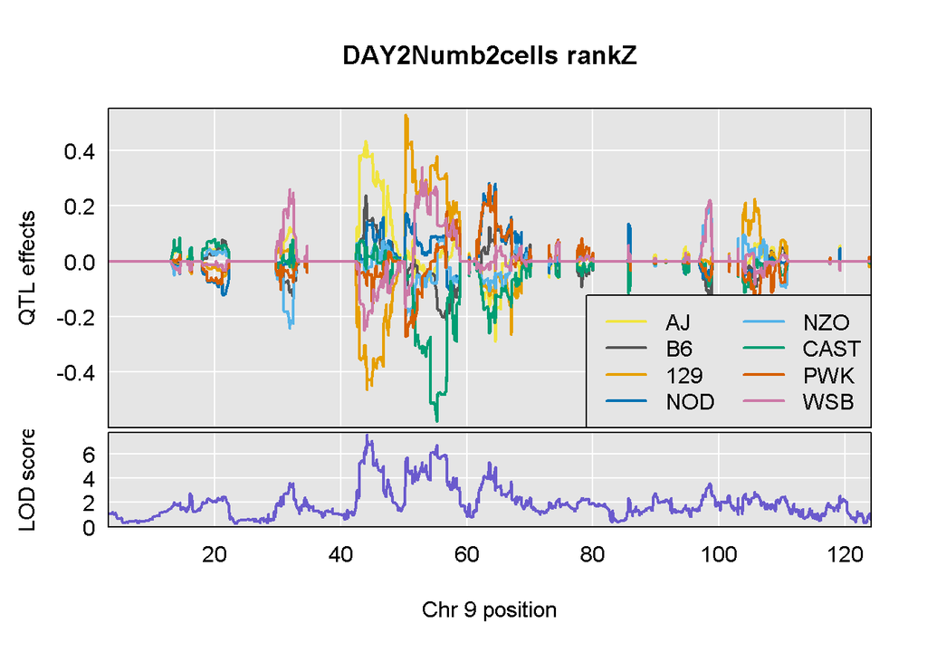

```r
chr = '9'
feff = scan1blup(genoprobs = probs[,chr],
                 pheno     = ph,
                 kinship   = K[[chr]],
                 addcovar  = addcovar)
plot_coefCC(feff, map, scan1_output = qtl, main = paste(pheno_name, 'rankZ'),
            legend = 'bottomright')
```

Run mediation analysis on the Chr 9 peak.

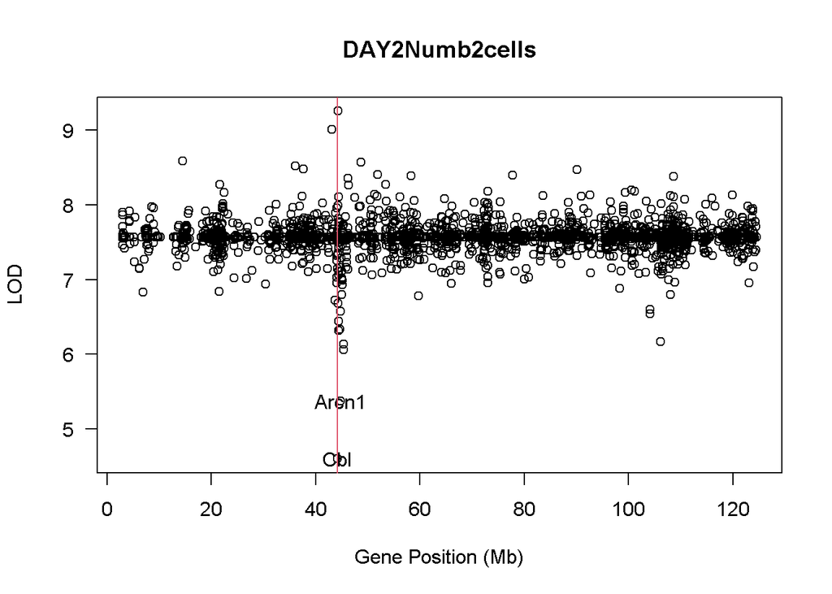

```r
med = mediation(pheno = ph, covar = addcovar, probs = probs, K = K, map = map,
                expr = norm_expr, annot = annot, chr = chr)
plot(med_lod ~ pos, data = med, las = 1, main = pheno_name,
     xlab = 'Gene Position (Mb)', ylab = 'LOD')
wh = which(med$med_lod < 6)
text(med$pos[wh], med$med_lod[wh], labels = med$symbol[wh])
abline(v = peaks$pos, col = 2)
```

*Cbl* page at Alliance for Genome Resources: https://www.alliancegenome.org/gene/MGI:88279

“Enables SH3 domain binding activity and ephrin receptor binding activity. Involved in regulation of platelet-derived growth factor receptor-alpha signaling pathway. Acts upstream of or within regulation of Rap protein signal transduction. Located in Golgi apparatus and cilium. Part of flotillin complex. Is expressed in male reproductive system and urinary system. Human ortholog(s) of this gene implicated in acute myeloid leukemia; juvenile myelomonocytic leukemia; lung non-small cell carcinoma; and myeloid neoplasm. Orthologous to human CBL (Cbl proto-oncogene).”

“Homozygotes for targeted null mutations exhibit increased thymic CD3 and CD4 expression and tyrosine-phosphorylation, lymphoid hyperplasia, and altered splenic hemopoiesis. Females show increased ductal density and branching in mammary fat pads.”

*Arcn1* page at Alliance for Genome Resources: https://www.alliancegenome.org/gene/MGI:2387591

“Acts upstream of or within several processes, including Golgi vesicle transport; adult locomotory behavior; and cerebellar Purkinje cell layer maturation. Located in COPI-coated vesicle; Golgi apparatus; and endoplasmic reticulum. Is expressed in several structures, including genitourinary system. Orthologous to human ARCN1 (archain 1).”

“Mice homozygous for a spontaneous mutation have a dilute coat color and neurological defects.”

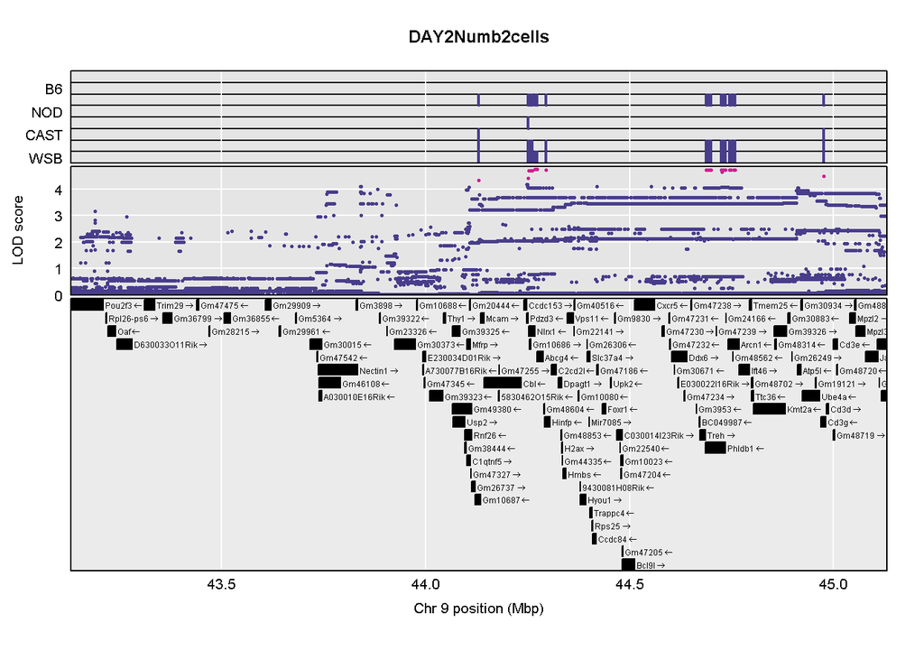

```r
peaks = find_peaks(qtl, map)
peaks = peaks[peaks$chr == chr,]
start = peaks$pos - 1
end   = peaks$pos + 1

assoc = scan1snps(genoprobs = probs[,chr], map = map, pheno = ph, kinship = K[[chr]],
                  addcovar = addcovar, query_func = snp_fxn, chr = chr, start = start,
                  end = end, keep_all_snps = TRUE)

g = gene_fxn(chr, start, end)
plot_snpasso(assoc$lod, assoc$snpinfo, drop_hilit = 0.5, genes = g, sdp_panel = TRUE,
             panel_prop = c(0.25, 0.2, 0.55), colors = 'black', main = pheno_name)
```

### Fertilized

Heritability: 0.48

Gather phenotype and covariates.

```r
pheno_name = 'Fertilized'
ph = pheno[,pheno_name, drop = FALSE]

meta_row  = which(meta$column == pheno_name)
transform = meta$transform[meta_row]

if(!is.na(transform)) {
  if(transform == 'log') {
    ph[,1] = log(ph[,1])
  } else if(transform == 'log1p') {
    ph[,1] = log1p(ph[,1])
  } else if(transform == 'sqrt') {
    ph[,1] = sqrt(ph[,1])
  }
} # if(!is.na(transform))

covar_names = strsplit(meta$covar[meta_row], split = ';')[[1]]
addcovar    = model.matrix(~ ., data = covar[,covar_names, drop = FALSE])[,-1, drop = FALSE]
```

Map phenotype with date as covariates.

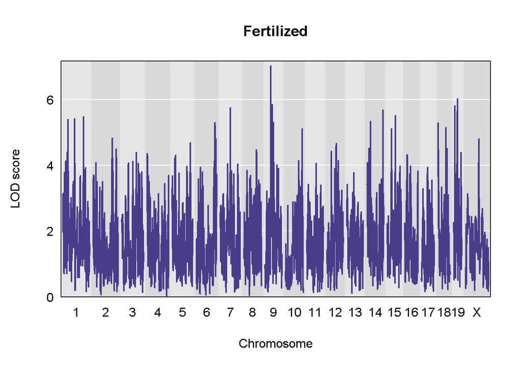

```r
qtl = scan1(genoprobs = probs,
            pheno     = ph,
            kinship   = K,
            addcovar  = addcovar)
plot(qtl, map, main = pheno_name)
```

Map Fertilized^2.

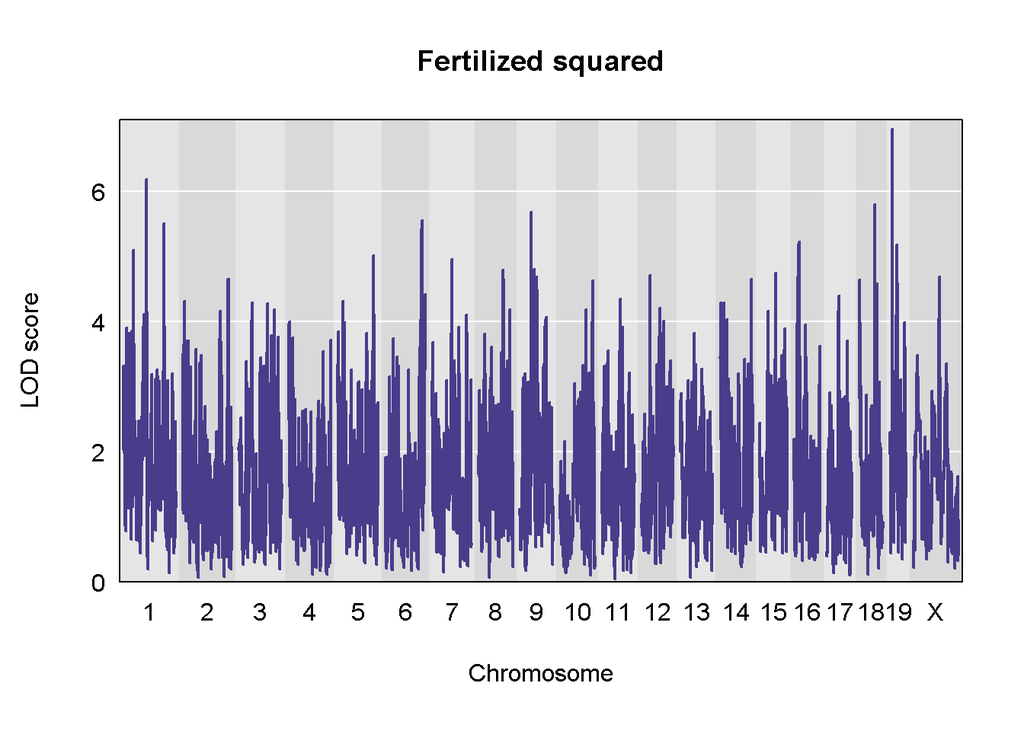

```r
ph[,1] = ph[,1]^2
qtl = scan1(genoprobs = probs,
            pheno     = ph,
            kinship   = K,
            addcovar  = addcovar)
plot(qtl, map, main = paste(pheno_name, 'squared'))
```

Map rankZ-transformed phenotype.

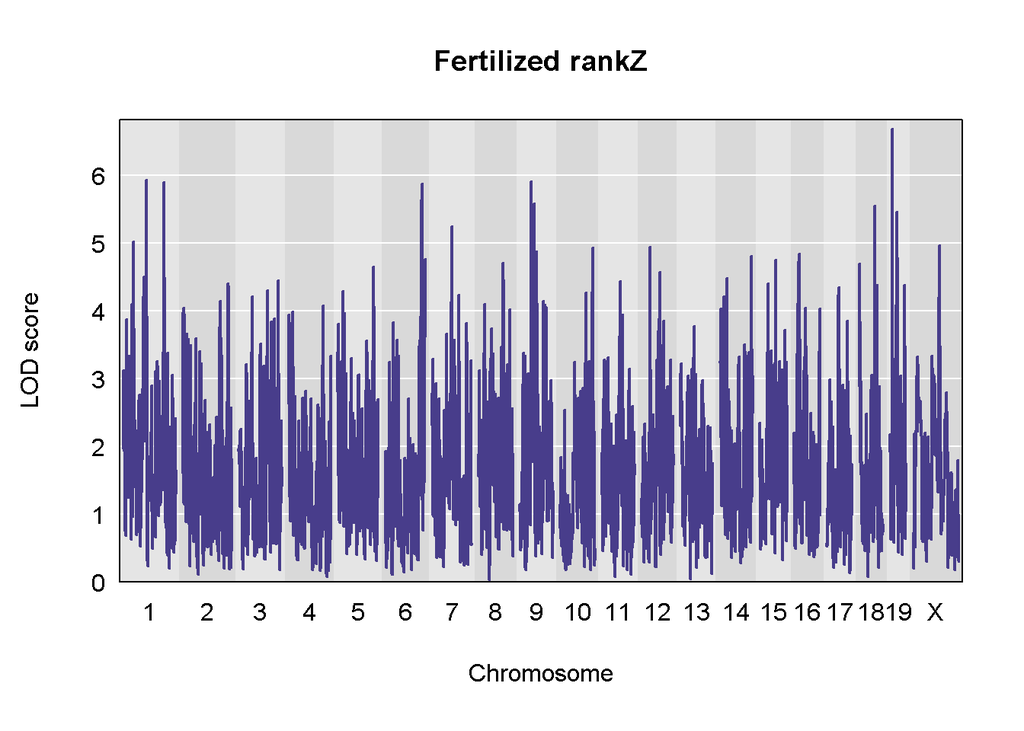

```r
ph  = pheno_rz[,pheno_name, drop = FALSE]
qtl = scan1(genoprobs = probs,
            pheno     = ph,
            kinship   = K,
            addcovar  = addcovar)
plot(qtl, map, main = paste(pheno_name, 'rankZ'))
```

```r
peaks = find_peaks(qtl, map, threshold = 7)
```

### Day 2 number of dead 2-cells

Heritability: 0.18

Gather phenotype and covariates.

```r
pheno_name = 'DAY2NumbDead'
ph = pheno[,pheno_name, drop = FALSE]

meta_row  = which(meta$column == pheno_name)
transform = meta$transform[meta_row]

if(!is.na(transform)) {
  if(transform == 'log') {
    ph[,1] = log(ph[,1])
  } else if(transform == 'log1p') {
    ph[,1] = log1p(ph[,1])
  } else if(transform == 'sqrt') {
    ph[,1] = sqrt(ph[,1])
  }
} # if(!is.na(transform))

covar_names = strsplit(meta$covar[meta_row], split = ';')[[1]]
addcovar    = model.matrix(~ ., data = covar[,covar_names, drop = FALSE])[,-1, drop = FALSE]
```

Map phenotype with date,DAY2Numb2cells as covariates.

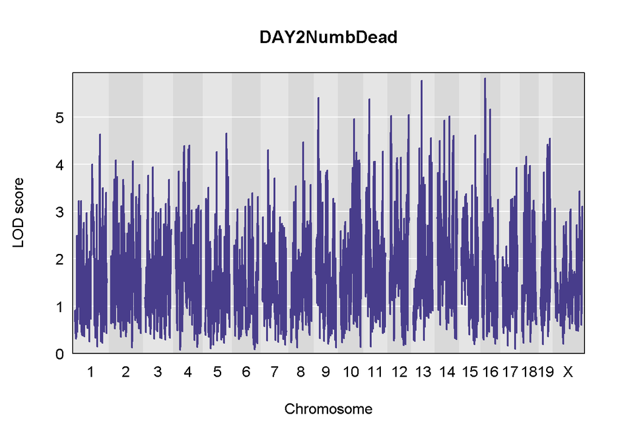

```r
qtl = scan1(genoprobs = probs,
            pheno     = ph,
            kinship   = K,
            addcovar  = addcovar)
plot(qtl, map, main = pheno_name)
```

Map rankZ-transformed phenotype.

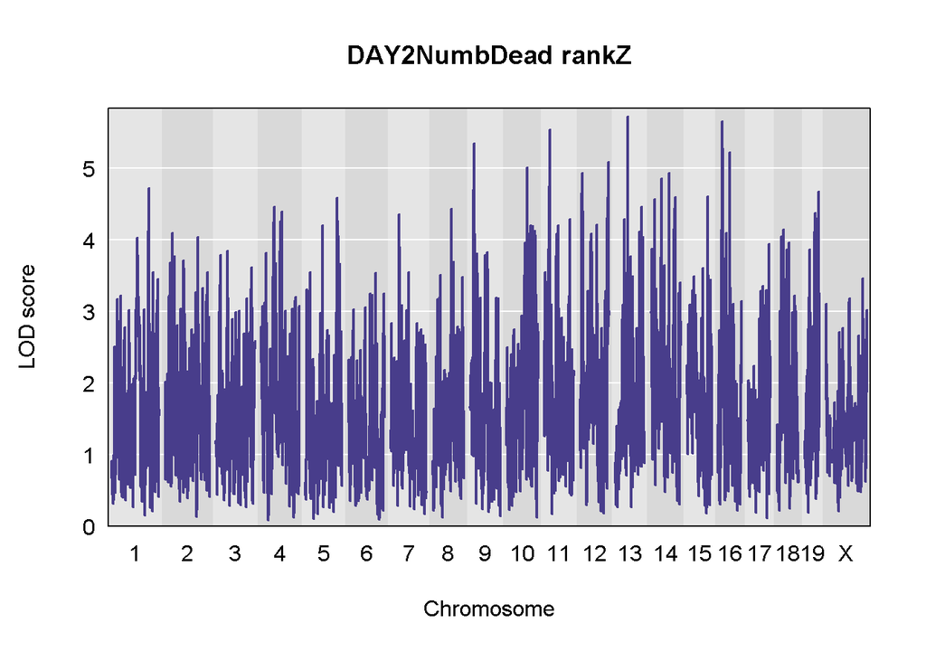

```r
ph  = pheno_rz[,pheno_name, drop = FALSE]
qtl = scan1(genoprobs = probs,
            pheno     = ph,
            kinship   = K,
            addcovar  = addcovar)
plot(qtl, map, main = paste(pheno_name, 'rankZ'))
```

### Day 2 number of fragmented 2-cells

Heritability: 0.19

Gather phenotype and covariates.

```r
pheno_name = 'DAY2NumbFrag'
ph = pheno[,pheno_name, drop = FALSE]

meta_row  = which(meta$column == pheno_name)
transform = meta$transform[meta_row]

if(!is.na(transform)) {
  if(transform == 'log') {
    ph[,1] = log(ph[,1])
  } else if(transform == 'log1p') {
    ph[,1] = log1p(ph[,1])
  } else if(transform == 'sqrt') {
    ph[,1] = sqrt(ph[,1])
  }
} # if(!is.na(transform))

covar_names = strsplit(meta$covar[meta_row], split = ';')[[1]]
addcovar    = model.matrix(~ ., data = covar[,covar_names, drop = FALSE])[,-1, drop = FALSE]
```

Map phenotype with date,DAY2Numb2cells as covariates.

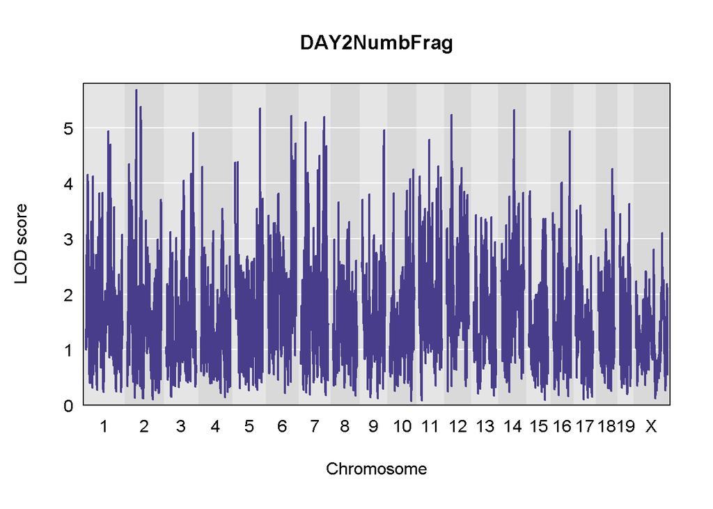

```r
qtl = scan1(genoprobs = probs,
            pheno     = ph,
            kinship   = K,
            addcovar  = addcovar)
plot(qtl, map, main = pheno_name)
```

Map rankZ-transformed phenotype.

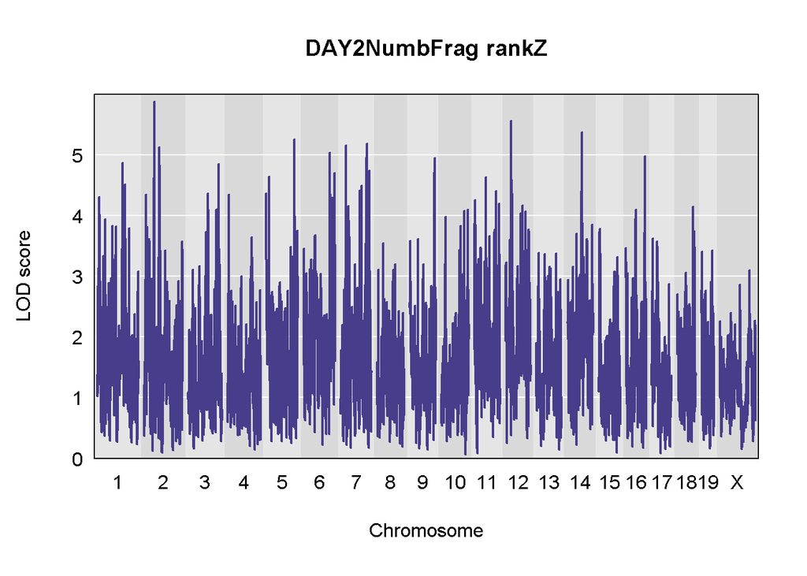

```r
ph  = pheno_rz[,pheno_name, drop = FALSE]
qtl = scan1(genoprobs = probs,
            pheno     = ph,
            kinship   = K,
            addcovar  = addcovar)
plot(qtl, map, main = paste(pheno_name, 'rankZ'))
```